# **Sentiment Analysis** **(Part - 1)**

# Adding Stock Features

Add all the features for stock data

```python
# Setting 'Date' column  in datetime format
stock_data['Date'] = pd.to_datetime(stock_data['Date'])
stock_data.set_index('Date', inplace=True)

# Calculate Moving Averages (MA)
stock_data['MA_7'] = stock_data['Adj Close'].rolling(window=7).mean()
stock_data['MA_20'] = stock_data['Adj Close'].rolling(window=20).mean()

# Calculate Exponential Moving Average (EMA)
stock_data['EMA'] = stock_data['Adj Close'].ewm(span=20, adjust=False).mean()

# Calculate Bollinger Bands
stock_data['MA_20_STD'] = stock_data['Adj Close'].rolling(window=20).std()
stock_data['Upper_Band'] = stock_data['MA_20'] + 2 * stock_data['MA_20_STD']
stock_data['Lower_Band'] = stock_data['MA_20'] - 2 * stock_data['MA_20_STD']



# Fill NaN values with the nearest valid values (forward fill and then backward fill)
stock_data.fillna(method='ffill', inplace=True)
stock_data.fillna(method='bfill', inplace=True)

# Resetting the index to keep 'Date' as a column
stock_data.reset_index(inplace=True)
```

Adding more features

```python
# Calculate Relative Strength Index (RSI)
delta = stock_data['Adj Close'].diff()
gain = delta.where(delta > 0, 0)
loss = -delta.where(delta < 0, 0)

avg_gain = gain.rolling(window=14).mean()
avg_loss = loss.rolling(window=14).mean()

rs = avg_gain / avg_loss
stock_data['RSI'] = 100 - (100 / (1 + rs))

# Calculate Moving Average Convergence Divergence (MACD)
short_ema = stock_data['Adj Close'].ewm(span=12, adjust=False).mean()
long_ema = stock_data['Adj Close'].ewm(span=26, adjust=False).mean()

stock_data['MACD'] = short_ema - long_ema
stock_data['Signal_Line'] = stock_data['MACD'].ewm(span=9, adjust=False).mean()

# Calculate Average True Range (ATR)
high_low_range = stock_data['High'] - stock_data['Low']
stock_data['ATR'] = high_low_range.rolling(window=14).mean()

# Calculate Commodity Channel Index (CCI)
typical_price = (stock_data['High'] + stock_data['Low'] + stock_data['Adj Close']) / 3
mean_deviation = (typical_price - typical_price.rolling(window=20).mean()).abs().rolling(window=20).mean()

stock_data['CCI'] = (typical_price - typical_price.rolling(window=20).mean()) / (0.015 * mean_deviation)

# Calculate Stochastic Oscillator
min_low = stock_data['Low'].rolling(window=14).min()
max_high = stock_data['High'].rolling(window=14).max()

stock_data['%K'] = ((stock_data['Adj Close'] - min_low) / (max_high - min_low)) * 100
stock_data['%D'] = stock_data['%K'].rolling(window=3).mean()
```

Plotting the Features

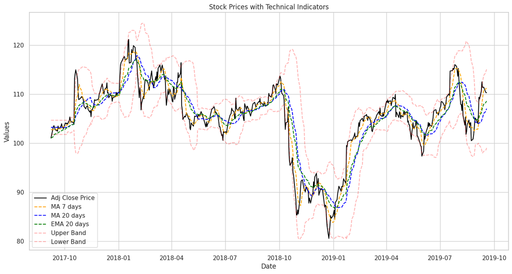

```python
import matplotlib.pyplot as plt

# Setting 'Date' column in datetime format
stock_data['Date'] = pd.to_datetime(stock_data['Date'])
stock_data.set_index('Date', inplace=True)

# Calculate Moving Averages (MA)
stock_data['MA_7'] = stock_data['Adj Close'].rolling(window=7).mean()
stock_data['MA_20'] = stock_data['Adj Close'].rolling(window=20).mean()

# Calculate Exponential Moving Average (EMA)
stock_data['EMA'] = stock_data['Adj Close'].ewm(span=20, adjust=False).mean()

# Calculate Bollinger Bands
stock_data['MA_20_STD'] = stock_data['Adj Close'].rolling(window=20).std()
stock_data['Upper_Band'] = stock_data['MA_20'] + 2 * stock_data['MA_20_STD']
stock_data['Lower_Band'] = stock_data['MA_20'] - 2 * stock_data['MA_20_STD']

# Fill NaN values with the nearest valid values (forward fill and then backward fill)
stock_data.fillna(method='ffill', inplace=True)
stock_data.fillna(method='bfill', inplace=True)

# Resetting the index to keep 'Date' as a column
stock_data.reset_index(inplace=True)

# Plotting all features in one graph
plt.figure(figsize=(16, 8))
plt.plot(stock_data['Date'], stock_data['Adj Close'], label='Adj Close Price', color='black')
plt.plot(stock_data['Date'], stock_data['MA_7'], label='MA 7 days', linestyle='--', color='orange')
plt.plot(stock_data['Date'], stock_data['MA_20'], label='MA 20 days', linestyle='--', color='blue')
plt.plot(stock_data['Date'], stock_data['EMA'], label='EMA 20 days', linestyle='--', color='green')
plt.plot(stock_data['Date'], stock_data['Upper_Band'], label='Upper Band', linestyle='--', color='red', alpha=0.3)
plt.plot(stock_data['Date'], stock_data['Lower_Band'], label='Lower Band', linestyle='--', color='red', alpha=0.3)

plt.title('Stock Prices with Technical Indicators')
plt.xlabel('Date')
plt.ylabel('Values')
plt.legend()
plt.grid(True)
plt.show()
```

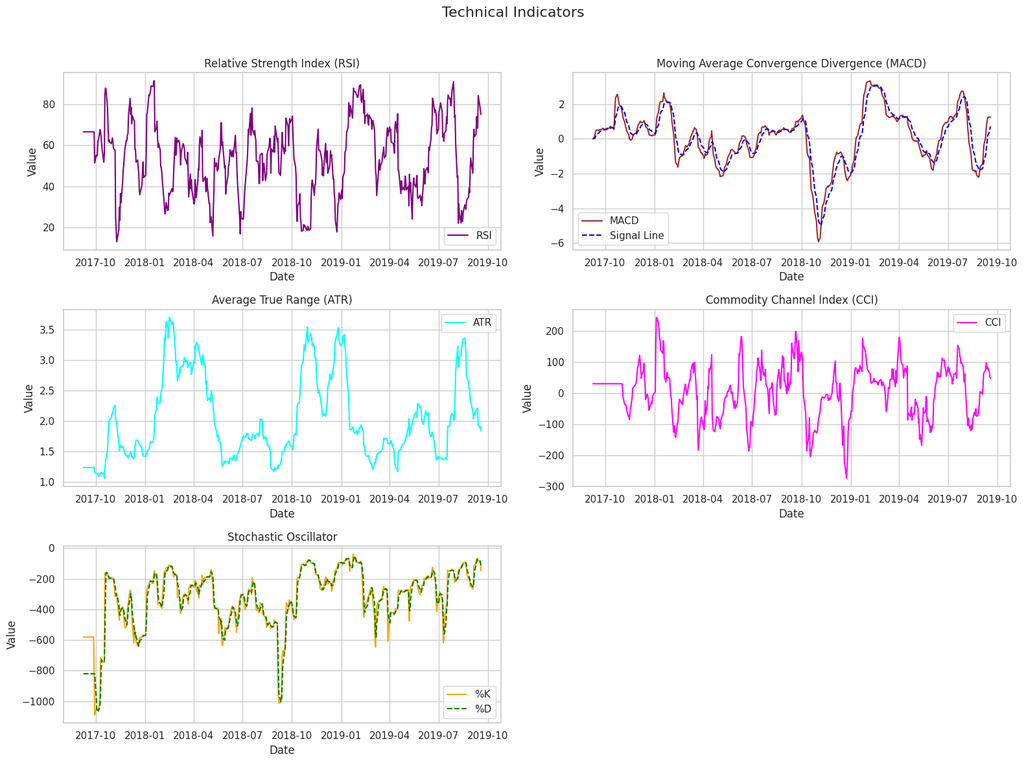

```python
# Plotting other features in separate graphs
fig, axes = plt.subplots(nrows=3, ncols=2, figsize=(16, 12))
fig.suptitle('Technical Indicators', fontsize=16)

# Plot 1: Relative Strength Index (RSI)
axes[0, 0].plot(stock_data['Date'], stock_data['RSI'], label='RSI', color='purple')
axes[0, 0].set_title('Relative Strength Index (RSI)')
axes[0, 0].set_xlabel('Date')
axes[0, 0].set_ylabel('Value')
axes[0, 0].legend()

# Plot 2: Moving Average Convergence Divergence (MACD)
axes[0, 1].plot(stock_data['Date'], stock_data['MACD'], label='MACD', color='brown')
axes[0, 1].plot(stock_data['Date'], stock_data['Signal_Line'], label='Signal Line', linestyle='--', color='blue')
axes[0, 1].set_title('Moving Average Convergence Divergence (MACD)')
axes[0, 1].set_xlabel('Date')
axes[0, 1].set_ylabel('Value')
axes[0, 1].legend()

# Plot 3: Average True Range (ATR)
axes[1, 0].plot(stock_data['Date'], stock_data['ATR'], label='ATR', color='cyan')
axes[1, 0].set_title('Average True Range (ATR)')
axes[1, 0].set_xlabel('Date')
axes[1, 0].set_ylabel('Value')
axes[1, 0].legend()

# Plot 4: Commodity Channel Index (CCI)
axes[1, 1].plot(stock_data['Date'], stock_data['CCI'], label='CCI', color='magenta')
axes[1, 1].set_title('Commodity Channel Index (CCI)')
axes[1, 1].set_xlabel('Date')
axes[1, 1].set_ylabel('Value')
axes[1, 1].legend()

# Plot 5: Stochastic Oscillator
axes[2, 0].plot(stock_data['Date'], stock_data['%K'], label='%K', color='orange')
axes[2, 0].plot(stock_data['Date'], stock_data['%D'], label='%D', linestyle='--', color='green')
axes[2, 0].set_title('Stochastic Oscillator')
axes[2, 0].set_xlabel('Date')
axes[2, 0].set_ylabel('Value')
axes[2, 0].legend()

# Remove empty subplot
fig.delaxes(axes[2, 1])

# Adjust layout for better spacing
plt.tight_layout(rect=[0, 0, 1, 0.96])

# Show the plots
plt.show()
```

```python
stock_data.head()
```

|  | Date | Open | High | Low | Close | Adj Close | Volume | MA_7 | MA_20 | EMA | MA_20_STD | Upper_Band | Lower_Band | RSI | MACD | Signal_Line | ATR | CCI | %K | %D |
| --- | --- | --- | --- | --- | --- | --- | --- | --- | --- | --- | --- | --- | --- | --- | --- | --- | --- | --- | --- | --- |
| 0 | 2017-09-08 | 136.854691 | 136.854691 | 135.411087 | 136.185471 | 101.079407 | 3521045 | 102.784405 | 103.247149 | 101.079407 | 0.725778 | 104.698704 | 101.795594 | 66.529175 | 0.000000 | 0.000000 | 1.235318 | 30.528908 | -580.076214 | -820.403894 |
| 1 | 2017-09-11 | 137.227539 | 138.747604 | 136.720840 | 138.489487 | 102.789444 | 4825616 | 102.784405 | 103.247149 | 101.242267 | 0.725778 | 104.698704 | 101.795594 | 66.529175 | 0.136413 | 0.027283 | 1.235318 | 30.528908 | -580.076214 | -820.403894 |
| 2 | 2017-09-12 | 138.728485 | 139.933075 | 138.154877 | 139.349899 | 103.428101 | 5479053 | 102.784405 | 103.247149 | 101.450442 | 0.725778 | 104.698704 | 101.795594 | 66.529175 | 0.292682 | 0.080363 | 1.235318 | 30.528908 | -580.076214 | -820.403894 |
| 3 | 2017-09-13 | 138.957932 | 139.856598 | 138.948380 | 139.569794 | 103.591301 | 4289646 | 102.784405 | 103.247149 | 101.654333 | 0.725778 | 104.698704 | 101.795594 | 66.529175 | 0.424798 | 0.149250 | 1.235318 | 30.528908 | -580.076214 | -820.403894 |
| 4 | 2017-09-14 | 139.445511 | 139.942642 | 139.110901 | 139.139572 | 103.271980 | 3929717 | 102.784405 | 103.247149 | 101.808395 | 0.725778 | 104.698704 | 101.795594 | 66.529175 | 0.497994 | 0.218999 | 1.235318 | 30.528908 | -580.076214 | -820.403894 |

# **Merging Sentiment and Stock Data Analysis** **(Part - 3)**

Loading Sentiment Analysis Dataset

```python
Sentiment_df = pd.read_csv('IBM_P1.csv', error_bad_lines=False)
```

```python
selected_columns = ['Date', 'final_sentiment_score', 'followers_count', 'vader_sentiment_score']
new_df = Sentiment_df[selected_columns]

# replace the original DataFrame with this new one
Sentiment_df = new_df.copy()
```

```python
import pandas as pd

# Assuming your DataFrame is named df
# If not, replace df with the actual name of your DataFrame

# Convert 'Date' to datetime type (if it's not already)
Sentiment_df['Date'] = pd.to_datetime(Sentiment_df['Date'])

# Group by 'Date' and calculate the mean of 'sentiment_score'
grouped_df = Sentiment_df.groupby('Date')['final_sentiment_score', 'vader_sentiment_score'].mean().reset_index()
```

```python
Sentiment_df = grouped_df
```

```python
Sentiment_df.head()
```

|  | Date | final_sentiment_score | vader_sentiment_score |
| --- | --- | --- | --- |
| 0 | 2017-09-08 | 0.142712 | 0.238160 |
| 1 | 2017-09-09 | 0.079669 | 0.135668 |
| 2 | 2017-09-10 | 0.095224 | 0.181245 |
| 3 | 2017-09-11 | 0.090513 | 0.131436 |
| 4 | 2017-09-12 | 0.130307 | 0.157098 |

```python
Sentiment_df.shape
```

```
(742, 3)
```

# Merging Both datasets

```python
# Convert 'Date' column to datetime64[ns] in both DataFrames
stock_data['Date'] = pd.to_datetime(stock_data['Date'])
Sentiment_df['Date'] = pd.to_datetime(Sentiment_df['Date'])
```

```python
Sentiment_df.shape
```

```
(742, 3)
```

```python
stock_data.shape
```

```
(510, 20)
```

```python
# Merge datasets on 'Date'
final_df = pd.merge(stock_data, Sentiment_df, on='Date', how='inner')
```

```python
final_df.shape
```

```
(510, 22)
```

```python
final_df.head()
```

|  | Date | Open | High | Low | Close | Adj Close | Volume | MA_7 | MA_20 | EMA | ... | Lower_Band | RSI | MACD | Signal_Line | ATR | CCI | %K | %D | final_sentiment_score | vader_sentiment_score |
| --- | --- | --- | --- | --- | --- | --- | --- | --- | --- | --- | --- | --- | --- | --- | --- | --- | --- | --- | --- | --- | --- |
| 0 | 2017-09-08 | 136.854691 | 136.854691 | 135.411087 | 136.185471 | 101.079407 | 3521045 | 102.784405 | 103.247149 | 101.079407 | ... | 101.795594 | 66.529175 | 0.000000 | 0.000000 | 1.235318 | 30.528908 | -580.076214 | -820.403894 | 0.142712 | 0.238160 |
| 1 | 2017-09-11 | 137.227539 | 138.747604 | 136.720840 | 138.489487 | 102.789444 | 4825616 | 102.784405 | 103.247149 | 101.242267 | ... | 101.795594 | 66.529175 | 0.136413 | 0.027283 | 1.235318 | 30.528908 | -580.076214 | -820.403894 | 0.090513 | 0.131436 |
| 2 | 2017-09-12 | 138.728485 | 139.933075 | 138.154877 | 139.349899 | 103.428101 | 5479053 | 102.784405 | 103.247149 | 101.450442 | ... | 101.795594 | 66.529175 | 0.292682 | 0.080363 | 1.235318 | 30.528908 | -580.076214 | -820.403894 | 0.130307 | 0.157098 |
| 3 | 2017-09-13 | 138.957932 | 139.856598 | 138.948380 | 139.569794 | 103.591301 | 4289646 | 102.784405 | 103.247149 | 101.654333 | ... | 101.795594 | 66.529175 | 0.424798 | 0.149250 | 1.235318 | 30.528908 | -580.076214 | -820.403894 | 0.102558 | 0.127043 |
| 4 | 2017-09-14 | 139.445511 | 139.942642 | 139.110901 | 139.139572 | 103.271980 | 3929717 | 102.784405 | 103.247149 | 101.808395 | ... | 101.795594 | 66.529175 | 0.497994 | 0.218999 | 1.235318 | 30.528908 | -580.076214 | -820.403894 | 0.110800 | 0.111731 |

5 rows × 22 columns

# Plotting sentiment with Close price

Checking the sentiment aggregated

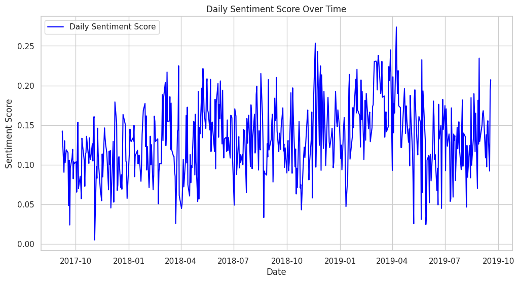

```python
import pandas as pd
import matplotlib.pyplot as plt

# Assuming 'Date' and 'final_sentiment_score' columns are present in your DataFrame
final_df['Date'] = pd.to_datetime(final_df['Date'])

plt.figure(figsize=(12, 6))
plt.plot(final_df['Date'], final_df['final_sentiment_score'], label='Daily Sentiment Score', color='blue')
plt.title('Daily Sentiment Score Over Time')
plt.xlabel('Date')
plt.ylabel('Sentiment Score')
plt.legend()
plt.show()
```

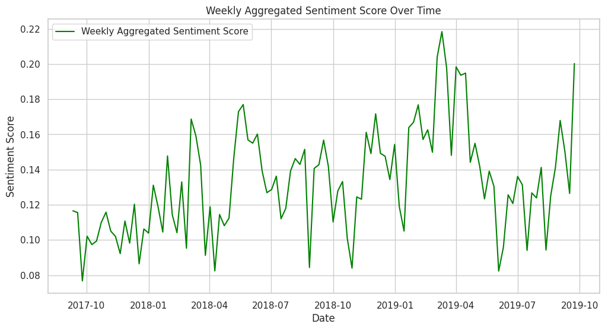

```python
import matplotlib.pyplot as plt

# Convert 'Date' column to datetime
final_df['Date'] = pd.to_datetime(final_df['Date'])  #

# Resample the data to get weekly averages
weekly_data = final_df.resample('W-Mon', on='Date').mean()

plt.figure(figsize=(12, 6))
plt.plot(weekly_data.index, weekly_data['final_sentiment_score'], label='Weekly Aggregated Sentiment Score', color='green')
plt.title('Weekly Aggregated Sentiment Score Over Time')
plt.xlabel('Date')
plt.ylabel('Sentiment Score')
plt.legend()
plt.show()
```

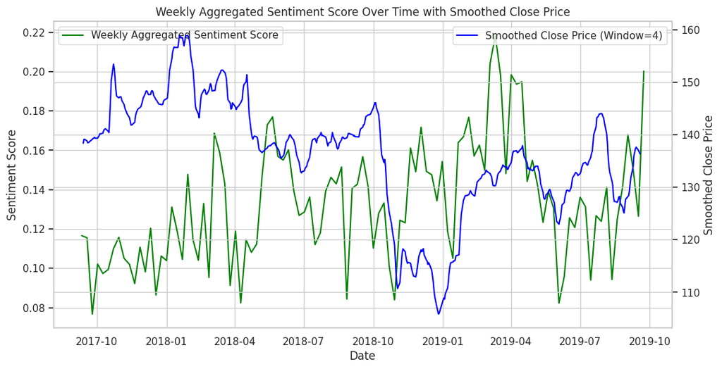

```python
import matplotlib.pyplot as plt
import pandas as pd

# Convert 'Date' column to datetime
final_df['Date'] = pd.to_datetime(final_df['Date'])

# Resample the data to get weekly averages
weekly_data = final_df.resample('W-Mon', on='Date').mean()

# Smooth 'Close' prices using a rolling mean
rolling_window = 4  # Adjust the window size as needed
smoothed_close = final_df['Close'].rolling(window=rolling_window).mean()

plt.figure(figsize=(12, 6))

# Plotting weekly aggregated sentiment score
plt.plot(weekly_data.index, weekly_data['final_sentiment_score'], label='Weekly Aggregated Sentiment Score', color='green')
plt.title('Weekly Aggregated Sentiment Score Over Time with Smoothed Close Price')
plt.xlabel('Date')
plt.ylabel('Sentiment Score')
plt.legend()

# Creating a secondary y-axis for the smoothed 'Close' prices
plt.twinx()
plt.plot(final_df['Date'], smoothed_close, label=f'Smoothed Close Price (Window={rolling_window})', color='blue')
plt.xlabel('Date')
plt.ylabel('Smoothed Close Price')
plt.legend()

plt.show()
```

# Correlation

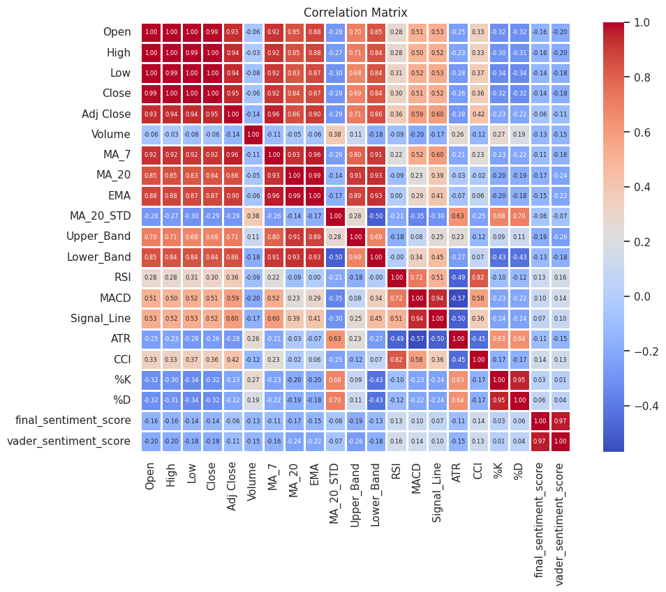

```python
import pandas as pd
import seaborn as sns
import matplotlib.pyplot as plt

# Remove non-numeric columns, as correlation is applicable to numeric data
numeric_columns = final_df.select_dtypes(include=['float64', 'int64']).columns
correlation_matrix = final_df[numeric_columns].corr()

# Set up the matplotlib figure size
plt.figure(figsize=(12, 8))

# Plot the correlation matrix as a heatmap with customized parameters
sns.heatmap(
    correlation_matrix,
    annot=True,
    cmap='coolwarm',
    fmt='.2f',
    linewidths=1,
    square=True,  # Ensures that each cell is a square
    cbar_kws={"shrink": 1},  # Adjusts the color bar size
    annot_kws={"fontsize": 6},  # Adjusts the font size of annotations
)

# Rotate the y-axis labels for better readability
plt.yticks(rotation=0)

# Showing the plot
plt.title('Correlation Matrix')
plt.show()
```

```python
# Columns to drop
columns_to_drop = ['Open', 'High', 'Low', 'Close', 'MA_7',	'MA_20',	'EMA',	'MA_20_STD',	'Upper_Band'	,'Lower_Band']

# Drop specified columns
final_df.drop(columns=columns_to_drop, inplace=True)
```

```python
final_df.head()
```

|  | Date | Adj Close | Volume | RSI | MACD | Signal_Line | ATR | CCI | %K | %D | final_sentiment_score | vader_sentiment_score |
| --- | --- | --- | --- | --- | --- | --- | --- | --- | --- | --- | --- | --- |
| 0 | 2017-09-08 | 101.079407 | 3521045 | 66.529175 | 0.000000 | 0.000000 | 1.235318 | 30.528908 | -580.076214 | -820.403894 | 0.142712 | 0.238160 |
| 1 | 2017-09-11 | 102.789444 | 4825616 | 66.529175 | 0.136413 | 0.027283 | 1.235318 | 30.528908 | -580.076214 | -820.403894 | 0.090513 | 0.131436 |
| 2 | 2017-09-12 | 103.428101 | 5479053 | 66.529175 | 0.292682 | 0.080363 | 1.235318 | 30.528908 | -580.076214 | -820.403894 | 0.130307 | 0.157098 |
| 3 | 2017-09-13 | 103.591301 | 4289646 | 66.529175 | 0.424798 | 0.149250 | 1.235318 | 30.528908 | -580.076214 | -820.403894 | 0.102558 | 0.127043 |
| 4 | 2017-09-14 | 103.271980 | 3929717 | 66.529175 | 0.497994 | 0.218999 | 1.235318 | 30.528908 | -580.076214 | -820.403894 | 0.110800 | 0.111731 |

# Selecting only numeric Data

```python
# Assuming your DataFrame is named final_df
numeric_columns = final_df.select_dtypes(include='number').columns

# Include the 'Date' column in the selection
numeric_columns = ['Date'] + list(numeric_columns)

# Create a new DataFrame with only numeric columns
numeric_df = final_df[numeric_columns]

#  modify the original DataFrame
final_df = final_df[numeric_columns]
```

```python
final_df.head()
```

|  | Date | Adj Close | Volume | RSI | MACD | Signal_Line | ATR | CCI | %K | %D | final_sentiment_score | vader_sentiment_score |
| --- | --- | --- | --- | --- | --- | --- | --- | --- | --- | --- | --- | --- |
| 0 | 2017-09-08 | 101.079407 | 3521045 | 66.529175 | 0.000000 | 0.000000 | 1.235318 | 30.528908 | -580.076214 | -820.403894 | 0.142712 | 0.238160 |
| 1 | 2017-09-11 | 102.789444 | 4825616 | 66.529175 | 0.136413 | 0.027283 | 1.235318 | 30.528908 | -580.076214 | -820.403894 | 0.090513 | 0.131436 |
| 2 | 2017-09-12 | 103.428101 | 5479053 | 66.529175 | 0.292682 | 0.080363 | 1.235318 | 30.528908 | -580.076214 | -820.403894 | 0.130307 | 0.157098 |
| 3 | 2017-09-13 | 103.591301 | 4289646 | 66.529175 | 0.424798 | 0.149250 | 1.235318 | 30.528908 | -580.076214 | -820.403894 | 0.102558 | 0.127043 |
| 4 | 2017-09-14 | 103.271980 | 3929717 | 66.529175 | 0.497994 | 0.218999 | 1.235318 | 30.528908 | -580.076214 | -820.403894 | 0.110800 | 0.111731 |

# LSTM Model and Evaluation

```python
# Import necessary libraries
import pandas as pd
import numpy as np
from sklearn.preprocessing import MinMaxScaler
from sklearn.metrics import mean_squared_error, r2_score
from sklearn.model_selection import train_test_split
from tensorflow.keras.models import Sequential
from tensorflow.keras.layers import LSTM, Dense
import matplotlib.pyplot as plt

df = final_df

# Convert 'Date' column to datetime format
df['Date'] = pd.to_datetime(df['Date'])

# Sort the DataFrame by Date
df = df.sort_values(by='Date')

# Set 'Date' as the index
df.set_index('Date', inplace=True)

# Feature selection
features = ['Adj Close', 'final_sentiment_score']
df = df[features]

# Normalize the dataset
scaler = MinMaxScaler(feature_range=(0, 1))
df_scaled = scaler.fit_transform(df)

# Function to create time series data
def create_time_series_data(data, time_steps=1):
    X, y = [], []
    for i in range(len(data) - time_steps):
        X.append(data[i:(i + time_steps), :])
        y.append(data[i + time_steps, 0])
    return np.array(X), np.array(y)

# Set the time steps
time_steps = 10

# Create time series data
X, y = create_time_series_data(df_scaled, time_steps)

# Split the data into training and testing sets
X_train, X_test, y_train, y_test = train_test_split(X, y, test_size=0.2, shuffle=False)

# Build the LSTM model
model = Sequential()
model.add(LSTM(units=50, return_sequences=True, input_shape=(X_train.shape[1], X_train.shape[2])))
model.add(LSTM(units=50))
model.add(Dense(units=1))
model.compile(optimizer='adam', loss='mean_squared_error')

# Train the model and record training and validation loss
history = model.fit(X_train, y_train, epochs=50, batch_size=32, validation_data=(X_test, y_test))

# Make predictions
y_pred = model.predict(X_test)

# Invert predictions to original scale
y_pred_inverse = scaler.inverse_transform(np.concatenate((y_pred, X_test[:, -1, 1:]), axis=1))[:, 0]

# Invert actual values to original scale
y_test_inverse = scaler.inverse_transform(np.concatenate((y_test.reshape(-1, 1), X_test[:, -1, 1:]), axis=1))[:, 0]
```

# Evaluation

Evaluating MSE, RMSE and R^2 Metrics

```python
# Evaluate the model
mse = mean_squared_error(y_test_inverse, y_pred_inverse)
rmse = np.sqrt(mse)
r2 = r2_score(y_test_inverse, y_pred_inverse)

# Print evaluation metrics
print(f'Mean Squared Error (MSE): {mse}')
print(f'Root Mean Squared Error (RMSE): {rmse}')
print(f'R-squared (R^2): {r2}')
```

```
Mean Squared Error (MSE): 3.678583942981326
Root Mean Squared Error (RMSE): 1.9179634884380166
R-squared (R^2): 0.808054241732673
```

Actual Price and Predicted Price Plot

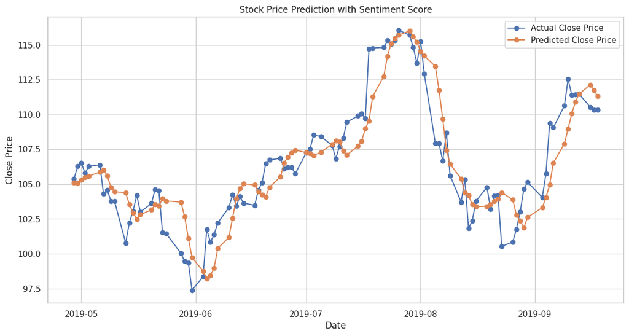

```python
# Plot the Actual Price and Predicted Price
plt.figure(figsize=(14, 7))
plt.plot(df.index[-len(y_test):], y_test_inverse, label='Actual Close Price', marker='o')
plt.plot(df.index[-len(y_test):], y_pred_inverse, label='Predicted Close Price', marker='o')
plt.title('Stock Price Prediction with Sentiment Score')
plt.xlabel('Date')
plt.ylabel('Close Price')
plt.legend()
plt.show()
```

Training Loss and Validation Loss

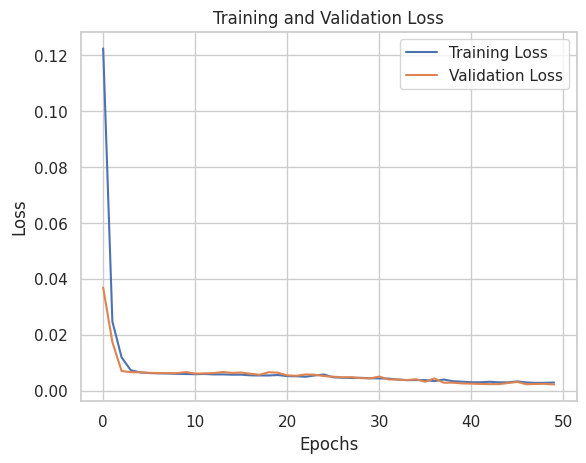

```python
# Plot training and validation loss
plt.plot(history.history['loss'], label='Training Loss')
plt.plot(history.history['val_loss'], label='Validation Loss')
plt.title('Training and Validation Loss')
plt.xlabel('Epochs')
plt.ylabel('Loss')
plt.legend()
plt.show()
```

## Percentage of Correct Direction (PCD)

```
Percentage of Correct Direction (PCD): 51.515151515151516%
```

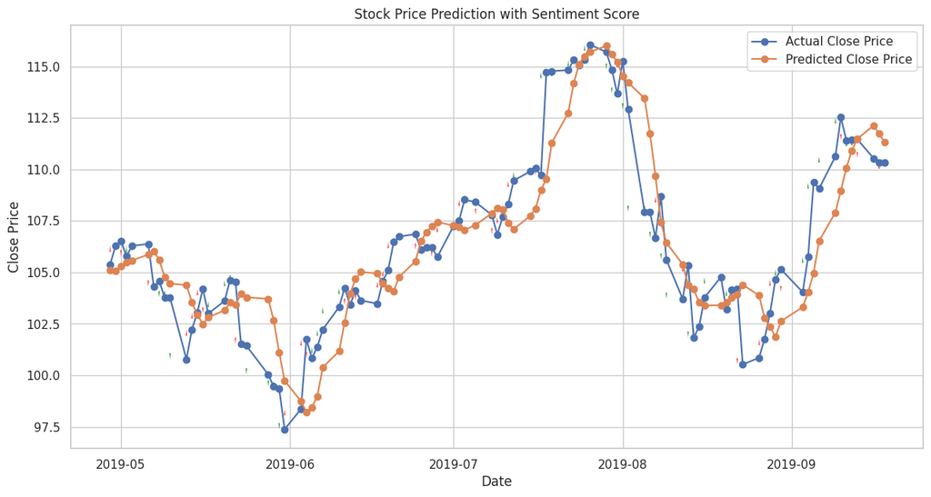

```python
# Calculate Percentage of Correct Direction (PCD)
pcd = np.mean(np.sign(y_pred_inverse[1:] - y_pred_inverse[:-1]) == np.sign(y_test_inverse[1:] - y_test_inverse[:-1])) * 100
print(f'Percentage of Correct Direction (PCD): {pcd}%')

# Plot the results with directional arrows
plt.figure(figsize=(14, 7))
plt.plot(df.index[-len(y_test):], y_test_inverse, label='Actual Close Price', marker='o')
plt.plot(df.index[-len(y_test):], y_pred_inverse, label='Predicted Close Price', marker='o')

# Add directional arrows to indicate correct and incorrect directions
for i in range(1, len(y_test_inverse)):
    actual_direction = np.sign(y_test_inverse[i] - y_test_inverse[i - 1])
    predicted_direction = np.sign(y_pred_inverse[i] - y_pred_inverse[i - 1])

    if actual_direction == predicted_direction:
        arrow_color = 'green'
    else:
        arrow_color = 'red'

    plt.arrow(df.index[-len(y_test) + i - 1], y_test_inverse[i - 1], 0, y_test_inverse[i] - y_test_inverse[i - 1],
              shape='full', lw=0, length_includes_head=True, head_width=0.2, color=arrow_color)

plt.title('Stock Price Prediction with Sentiment Score')
plt.xlabel('Date')
plt.ylabel('Close Price')
plt.legend()
plt.show()
```

# With Different Learning rates and Batch Sizes

```
Optimizer: Adam, Learning Rate: 0.1, Batch Size: 4
Mean Squared Error (MSE): 39.69312371355895
Root Mean Squared Error (RMSE): 6.300247908896836
R-squared (R^2): -1.0711575017160246
```

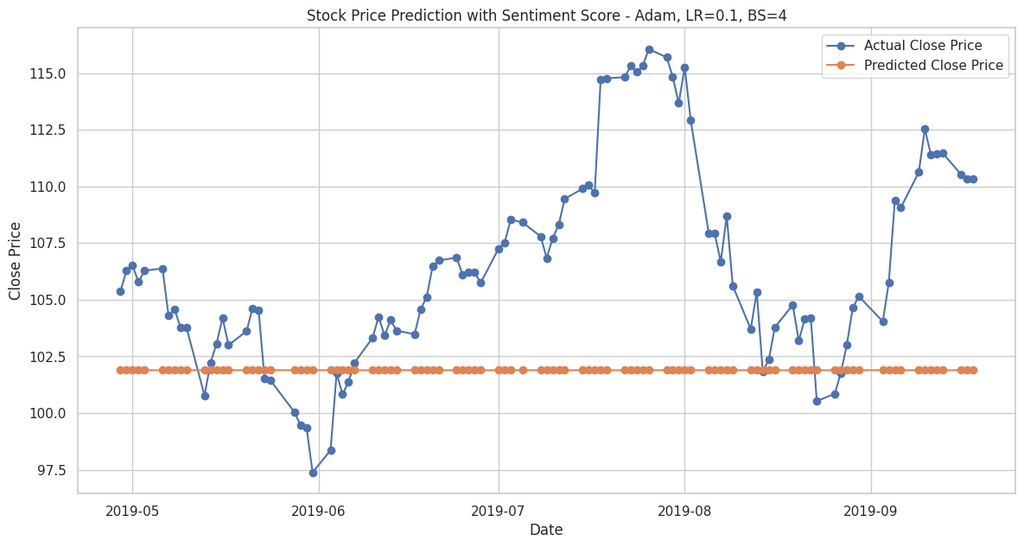

```
Optimizer: Adam, Learning Rate: 0.1, Batch Size: 8
Mean Squared Error (MSE): 28.10466288576939
Root Mean Squared Error (RMSE): 5.301383110639089
R-squared (R^2): -0.46648028482518455
```

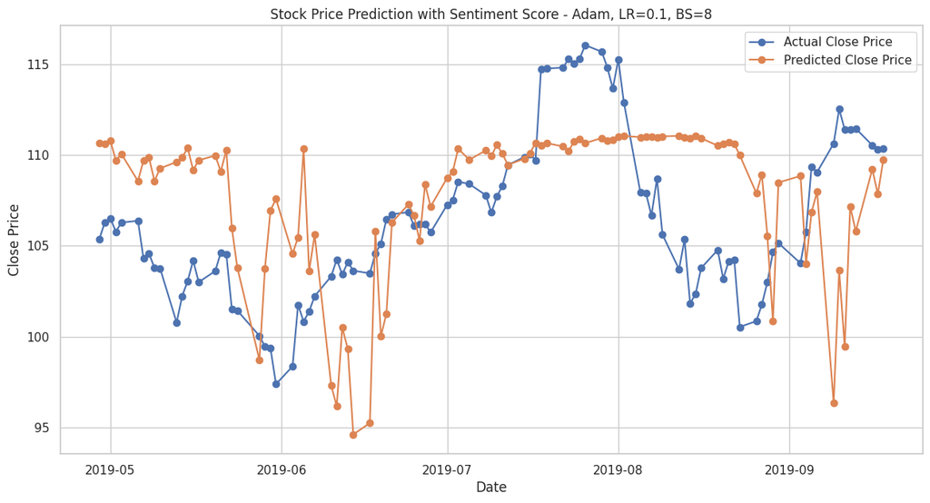

```
Optimizer: Adam, Learning Rate: 0.1, Batch Size: 16
Mean Squared Error (MSE): 19.08116705825705
Root Mean Squared Error (RMSE): 4.3681995213425235
R-squared (R^2): 0.004358977151855181
```

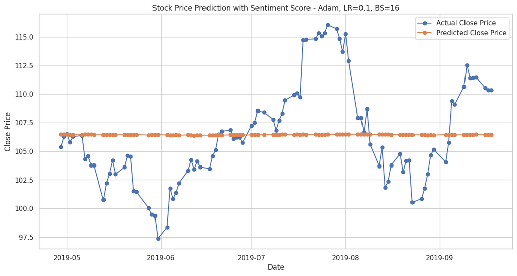

```
Optimizer: Adam, Learning Rate: 0.01, Batch Size: 4
Mean Squared Error (MSE): 2.9321851643443426
Root Mean Squared Error (RMSE): 1.7123624512188833
R-squared (R^2): 0.8470007716354732
```

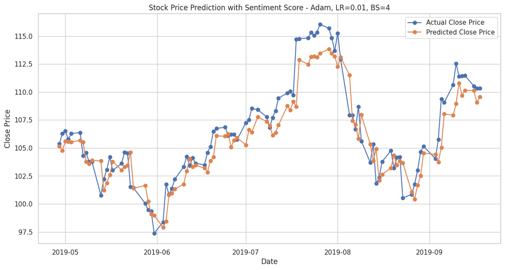

```
Optimizer: Adam, Learning Rate: 0.01, Batch Size: 8
Mean Squared Error (MSE): 5.340729108353272
Root Mean Squared Error (RMSE): 2.3110017542947197
R-squared (R^2): 0.7213247504221878
```

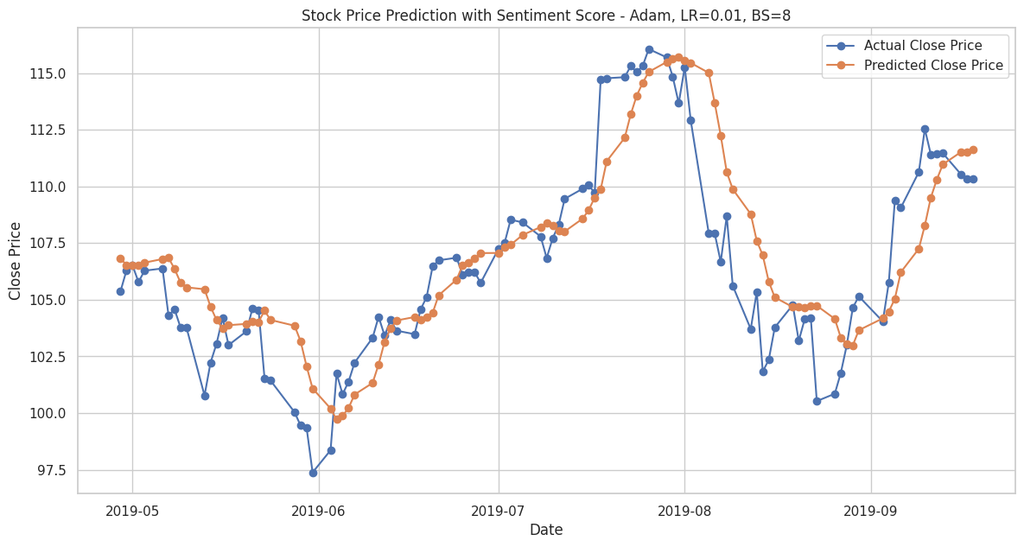

```
Optimizer: Adam, Learning Rate: 0.01, Batch Size: 16
Mean Squared Error (MSE): 9.632487268229205
Root Mean Squared Error (RMSE): 3.103624859455344
R-squared (R^2): 0.4973840202210622
```

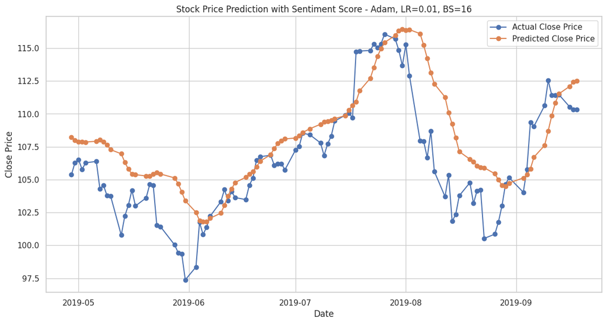

```
Optimizer: Adam, Learning Rate: 0.001, Batch Size: 4
Mean Squared Error (MSE): 8.977468655232297
Root Mean Squared Error (RMSE): 2.996242422640781
R-squared (R^2): 0.5315624014404963
```

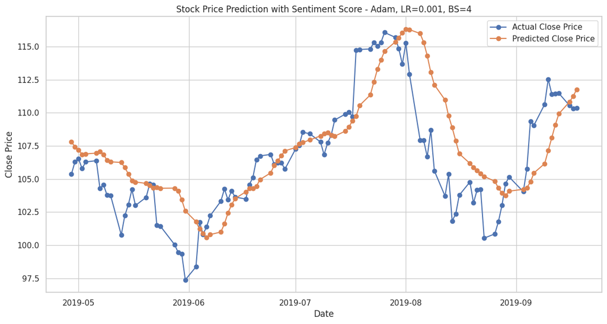

```
Optimizer: Adam, Learning Rate: 0.001, Batch Size: 8
Mean Squared Error (MSE): 9.22208286930998
Root Mean Squared Error (RMSE): 3.0367882490074907
R-squared (R^2): 0.5187986147410811
```

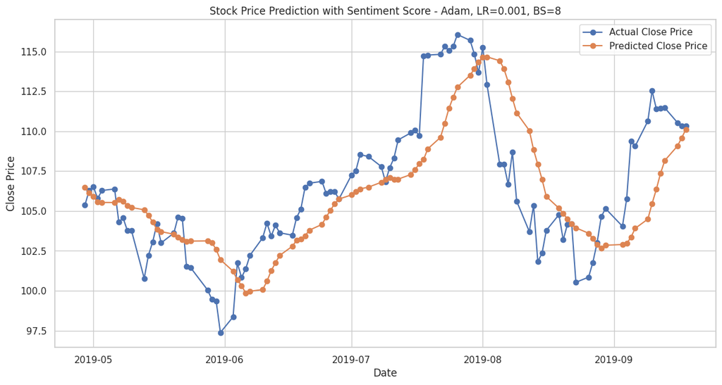

```
Optimizer: Adam, Learning Rate: 0.001, Batch Size: 16
Mean Squared Error (MSE): 10.005153383042213
Root Mean Squared Error (RMSE): 3.163092376621684
R-squared (R^2): 0.477938581134426
```

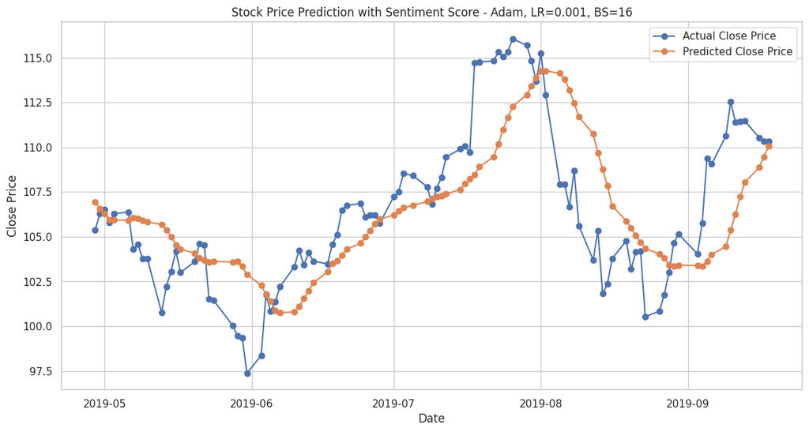

```
Optimizer: Adagrad, Learning Rate: 0.1, Batch Size: 4
Mean Squared Error (MSE): 13.488686204804853
Root Mean Squared Error (RMSE): 3.672694678952343
R-squared (R^2): 0.2961704444583222
```

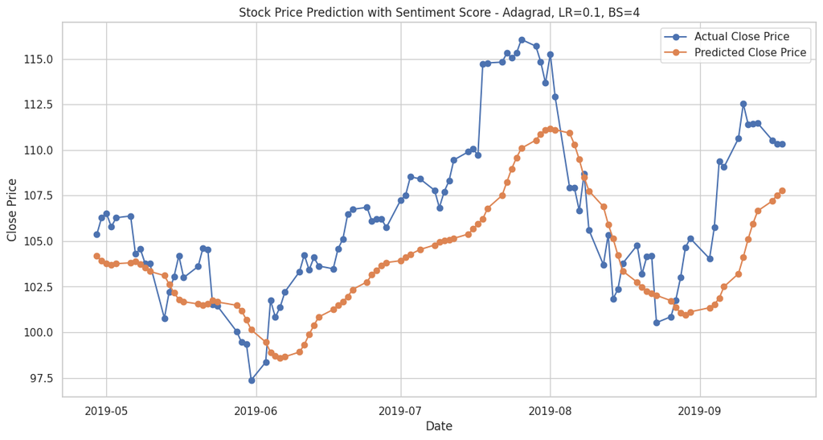

```
Optimizer: Adagrad, Learning Rate: 0.1, Batch Size: 8
Mean Squared Error (MSE): 8.113786556416876
Root Mean Squared Error (RMSE): 2.8484709154942895
R-squared (R^2): 0.5766286872528257
```

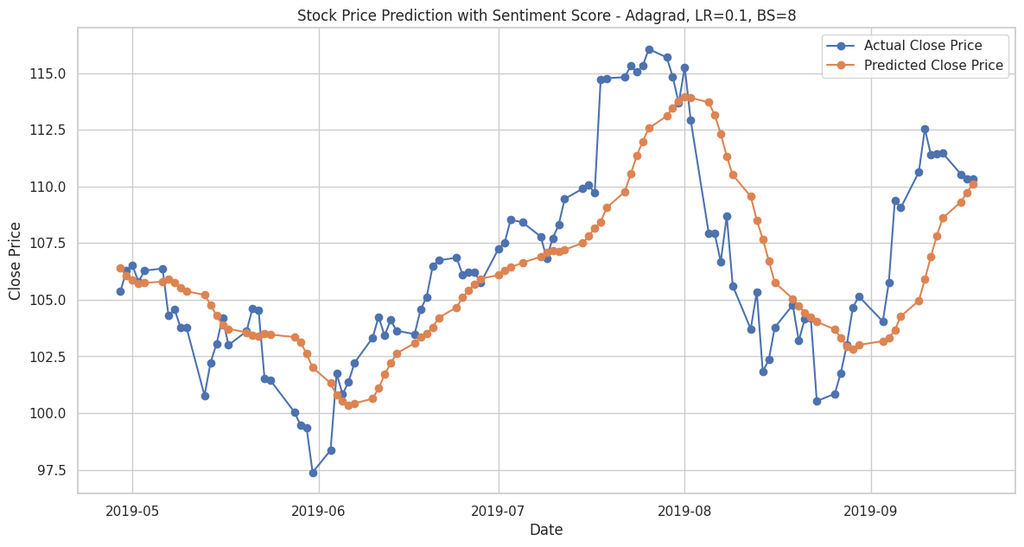

```
Optimizer: Adagrad, Learning Rate: 0.1, Batch Size: 16
Mean Squared Error (MSE): 23.65066203051029
Root Mean Squared Error (RMSE): 4.8631946321847215
R-squared (R^2): -0.2340738521495851
```

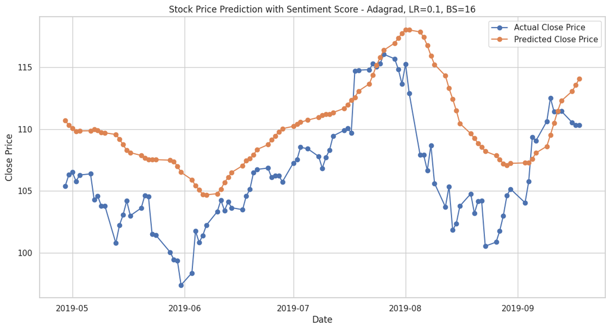

```
Optimizer: Adagrad, Learning Rate: 0.01, Batch Size: 4
Mean Squared Error (MSE): 9.885419844395562
Root Mean Squared Error (RMSE): 3.1441087519988176
R-squared (R^2): 0.4841861876106658
```

[15 more figures not shown]

```python
# Import necessary libraries
import pandas as pd
import numpy as np
from sklearn.preprocessing import MinMaxScaler
from sklearn.metrics import mean_squared_error, r2_score
from sklearn.model_selection import train_test_split
from tensorflow.keras.models import Sequential
from tensorflow.keras.layers import LSTM, Dense
from tensorflow.keras.optimizers import Adam, Adagrad, Nadam
import matplotlib.pyplot as plt

df = final_df

# Convert 'Date' column to datetime format
df['Date'] = pd.to_datetime(df['Date'])

# Sort the DataFrame by Date
df = df.sort_values(by='Date')

# Set 'Date' as the index
df.set_index('Date', inplace=True)

# Feature selection
features = ['Adj Close', 'final_sentiment_score']
df = df[features]

# Normalize the dataset
scaler = MinMaxScaler(feature_range=(0, 1))
df_scaled = scaler.fit_transform(df)

# Function to create time series data
def create_time_series_data(data, time_steps=1):
    X, y = [], []
    for i in range(len(data) - time_steps):
        X.append(data[i:(i + time_steps), :])
        y.append(data[i + time_steps, 0])
    return np.array(X), np.array(y)

# Set the time steps
time_steps = 10

# Create time series data
X, y = create_time_series_data(df_scaled, time_steps)

# Split the data into training and testing sets
X_train, X_test, y_train, y_test = train_test_split(X, y, test_size=0.2, shuffle=False)

# Define hyperparameters
optimizer_names = ['Adam', 'Adagrad', 'Nadam']
learning_rates = [0.1, 0.01, 0.001]
batch_sizes = [4, 8, 16]

# Iterate through different hyperparameters
for optimizer_name in optimizer_names:
    for learning_rate in learning_rates:
        for batch_size in batch_sizes:
            # Build the LSTM model
            model = Sequential()
            if optimizer_name == 'Adam':
                optimizer = Adam(learning_rate=learning_rate)
            elif optimizer_name == 'Adagrad':
                optimizer = Adagrad(learning_rate=learning_rate)
            elif optimizer_name == 'Nadam':
                optimizer = Nadam(learning_rate=learning_rate)

            model.add(LSTM(units=50, return_sequences=True, input_shape=(X_train.shape[1], X_train.shape[2])))
            model.add(LSTM(units=50))
            model.add(Dense(units=1))
            model.compile(optimizer=optimizer, loss='mean_squared_error')

            # Train the model and record training and validation loss
            history = model.fit(X_train, y_train, epochs=5, batch_size=batch_size, validation_data=(X_test, y_test), verbose=0)

            # Make predictions
            y_pred = model.predict(X_test)

            # Invert predictions to original scale
            y_pred_inverse = scaler.inverse_transform(np.concatenate((y_pred, X_test[:, -1, 1:]), axis=1))[:, 0]

            # Invert actual values to original scale
            y_test_inverse = scaler.inverse_transform(np.concatenate((y_test.reshape(-1, 1), X_test[:, -1, 1:]), axis=1))[:, 0]

            # Evaluate the model
            mse = mean_squared_error(y_test_inverse, y_pred_inverse)
            rmse = np.sqrt(mse)
            r2 = r2_score(y_test_inverse, y_pred_inverse)

            # Print evaluation metrics
            print(f'Optimizer: {optimizer_name}, Learning Rate: {learning_rate}, Batch Size: {batch_size}')
            print(f'Mean Squared Error (MSE): {mse}')
            print(f'Root Mean Squared Error (RMSE): {rmse}')
            print(f'R-squared (R^2): {r2}\n')

            # Plot the Actual Price and Predicted Price
            plt.figure(figsize=(14, 7))
            plt.plot(df.index[-len(y_test):], y_test_inverse, label='Actual Close Price', marker='o')
            plt.plot(df.index[-len(y_test):], y_pred_inverse, label='Predicted Close Price', marker='o')
            plt.title(f'Stock Price Prediction with Sentiment Score - {optimizer_name}, LR={learning_rate}, BS={batch_size}')
            plt.xlabel('Date')
            plt.ylabel('Close Price')
            plt.legend()
            plt.show()
```

# Cross Validation

```python
# Import necessary libraries
from sklearn.model_selection import KFold

# Define number of folds
num_folds = 5
kf = KFold(n_splits=num_folds, shuffle=True, random_state=42)

# Initialize lists to store evaluation metrics
mse_scores, rmse_scores, r2_scores = [], [], []

# Initialize lists to store training and validation loss for each fold
train_losses, val_losses = [], []

# Perform 5-fold cross-validation
for train_index, val_index in kf.split(X):
    X_train, X_val = X[train_index], X[val_index]
    y_train, y_val = y[train_index], y[val_index]

    # Build the LSTM model
    model = Sequential()
    model.add(LSTM(units=50, return_sequences=True, input_shape=(X_train.shape[1], X_train.shape[2])))
    model.add(LSTM(units=50))
    model.add(Dense(units=1))
    model.compile(optimizer='adam', loss='mean_squared_error')

    # Train the model and record training and validation loss
    history = model.fit(X_train, y_train, epochs=5, batch_size=32, validation_data=(X_val, y_val), verbose=0)

    # Evaluate the model on validation set
    val_loss = model.evaluate(X_val, y_val)

    # Record training and validation loss for this fold
    train_losses.append(history.history['loss'])
    val_losses.append(history.history['val_loss'])

    # Make predictions
    y_pred = model.predict(X_val)

    # Invert predictions to original scale
    y_pred_inverse = scaler.inverse_transform(np.concatenate((y_pred, X_val[:, -1, 1:]), axis=1))[:, 0]

    # Invert actual values to original scale
    y_val_inverse = scaler.inverse_transform(np.concatenate((y_val.reshape(-1, 1), X_val[:, -1, 1:]), axis=1))[:, 0]

    # Calculate evaluation metrics
    mse = mean_squared_error(y_val_inverse, y_pred_inverse)
    rmse = np.sqrt(mse)
    r2 = r2_score(y_val_inverse, y_pred_inverse)

    # Record evaluation metrics for this fold
    mse_scores.append(mse)
    rmse_scores.append(rmse)
    r2_scores.append(r2)
```

```python
# Display evaluation metrics
print(f'Mean MSE: {np.mean(mse_scores)}')
print(f'Mean RMSE: {np.mean(rmse_scores)}')
print(f'Mean R^2: {np.mean(r2_scores)}')
```

```
Mean MSE: 10.863583648792922
Mean RMSE: 3.2679713624728386
Mean R^2: 0.7984953159228902
```

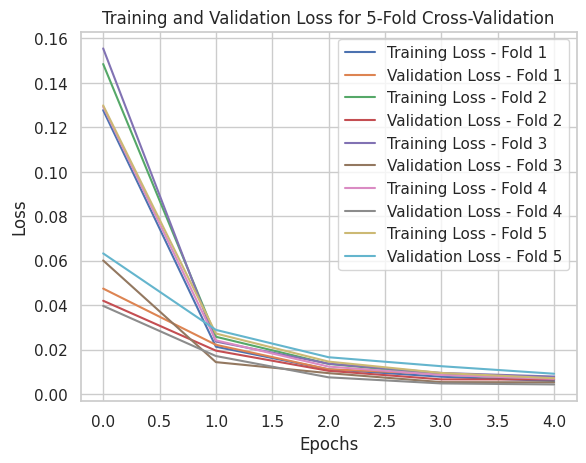

```python
# Plot training and validation loss for each fold
for i in range(num_folds):
    plt.plot(train_losses[i], label=f'Training Loss - Fold {i + 1}')
    plt.plot(val_losses[i], label=f'Validation Loss - Fold {i + 1}')

plt.xlabel('Epochs')
plt.ylabel('Loss')
plt.title('Training and Validation Loss for 5-Fold Cross-Validation')
plt.legend()
plt.show()
```

```python
# Import necessary libraries
from sklearn.model_selection import KFold

# Define number of folds
num_folds = 5
kf = KFold(n_splits=num_folds, shuffle=True, random_state=42)

# Initialize lists to store evaluation metrics
mse_scores, rmse_scores, r2_scores = [], [], []

# Initialize lists to store training and validation loss for each fold
train_losses, val_losses = [], []

# Perform 5-fold cross-validation
for train_index, val_index in kf.split(X):
    X_train, X_val = X[train_index], X[val_index]
    y_train, y_val = y[train_index], y[val_index]

    # Build the LSTM model
    model = Sequential()
    model.add(LSTM(units=50, return_sequences=True, input_shape=(X_train.shape[1], X_train.shape[2])))
    model.add(LSTM(units=50))
    model.add(Dense(units=1))
    model.compile(optimizer='adam', loss='mean_squared_error')

    # Train the model and record training and validation loss
    history = model.fit(X_train, y_train, epochs=10, batch_size=32, validation_data=(X_val, y_val), verbose=0)

    # Evaluate the model on validation set
    val_loss = model.evaluate(X_val, y_val)

    # Record training and validation loss for this fold
    train_losses.append(history.history['loss'])
    val_losses.append(history.history['val_loss'])

    # Make predictions
    y_pred = model.predict(X_val)

    # Invert predictions to original scale
    y_pred_inverse = scaler.inverse_transform(np.concatenate((y_pred, X_val[:, -1, 1:]), axis=1))[:, 0]

    # Invert actual values to original scale
    y_val_inverse = scaler.inverse_transform(np.concatenate((y_val.reshape(-1, 1), X_val[:, -1, 1:]), axis=1))[:, 0]

    # Calculate evaluation metrics
    mse = mean_squared_error(y_val_inverse, y_pred_inverse)
    rmse = np.sqrt(mse)
    r2 = r2_score(y_val_inverse, y_pred_inverse)

    # Record evaluation metrics for this fold
    mse_scores.append(mse)
    rmse_scores.append(rmse)
    r2_scores.append(r2)
```

```python
# Display evaluation metrics
print(f'Mean MSE: {np.mean(mse_scores)}')
print(f'Mean RMSE: {np.mean(rmse_scores)}')
print(f'Mean R^2: {np.mean(r2_scores)}')
```

```
Mean MSE: 9.668467193899529
Mean RMSE: 3.083083499898245
Mean R^2: 0.8202448342018132
```

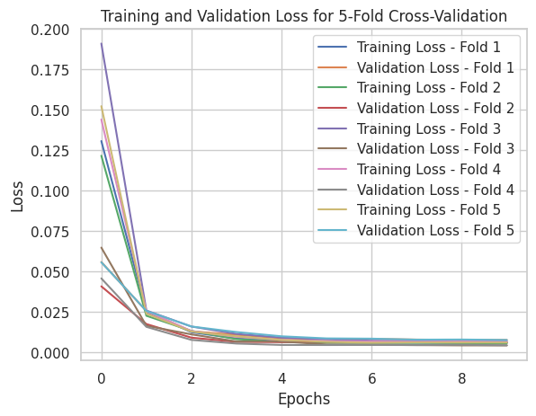

```python
# Plot training and validation loss for each fold
for i in range(num_folds):
    plt.plot(train_losses[i], label=f'Training Loss - Fold {i + 1}')
    plt.plot(val_losses[i], label=f'Validation Loss - Fold {i + 1}')

plt.xlabel('Epochs')
plt.ylabel('Loss')
plt.title('Training and Validation Loss for 5-Fold Cross-Validation')
plt.legend()
plt.show()
```

# Diagnosis of Model

## QQ Plot (Quantile-Quantile Plot)

This plot compares the quantiles of the residuals with the quantiles of a theoretical normal distribution. Deviations from a straight line might indicate non-normality.

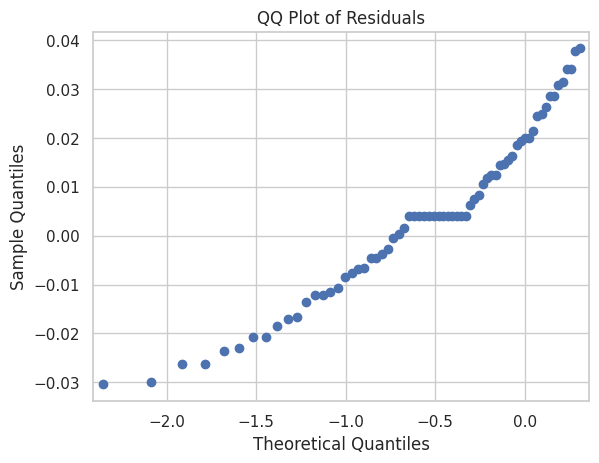

```python
import statsmodels.api as sm

# Create QQ plot
sm.qqplot(residuals, line='s')
plt.title('QQ Plot of Residuals')
plt.show()
```